# FigureYa145target

**Author(s)**: Long Zhao  
**Reviewer(s)**: Ying Ge, Junyi Shen  
**Date**: 2025-10-17

## Academic Citation

If you use this code in your work or research, we kindly request that you cite our publication:

Xiaofan Lu, et al. (2025). FigureYa: A Standardized Visualization Framework for Enhancing Biomedical Data Interpretation and Research Efficiency. iMetaMed. https://doi.org/10.1002/imm3.70005

## 需求描述

## Requirement description

从形式上复现原图。 Reproduce the original image in form.

有时没有现成的包能画出一模一样的图，我们可以通过计算图中每个元素的位置，然后画出想要的效果。 Sometimes there is no ready-made package that can draw the same image. We can calculate the position of each element in the image and then draw the desired effect.

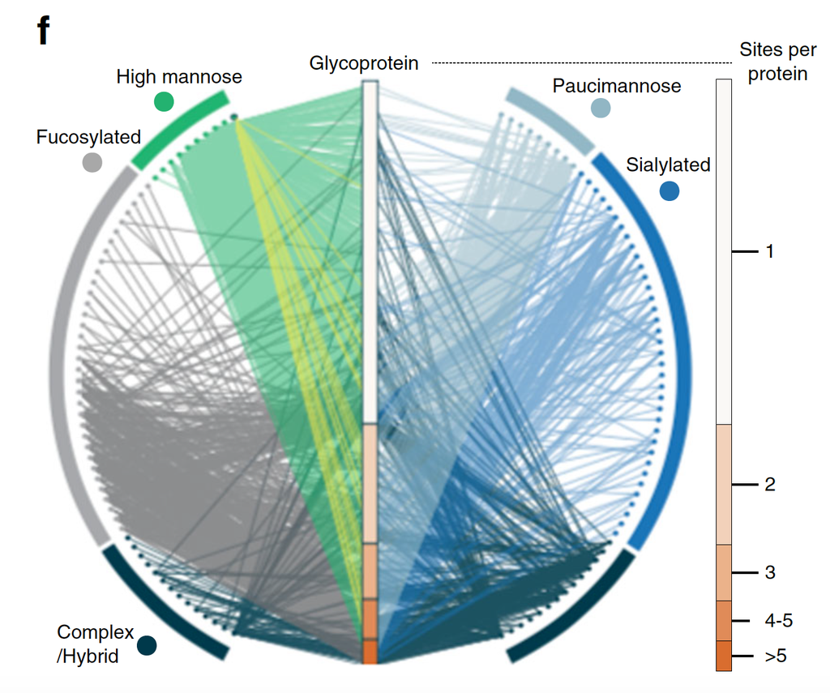

出自https://www.nature.com/articles/s41467-019-09222-w From https://www.nature.com/articles/s41467-019-09222-w

Fig. 2 Characteristics of glycosites identified with AI-ETD. f A glycoprotein-glycan network maps **which glycans (outer circle, 117 total) modify which proteins (inner bar, 771 total)**. Glycoproteins are **sorted by number of glycosites (scale to the right)**. Glycans are organized by classification, and **edges are colored by the glycan node from which they originate**, except for mannose-6-phosphate which has yellow edges. See Supplementary Fig. 11 and Supplementary Table 1 for glycan identifiers.

A glycoprotein-glycan network diagram in Fig. 2f maps which glycans (outer nodes) were observed on identified glycoproteins (inner column, organized by number of glycosites). Several discernable patterns appear, perhaps most notably the prevalence of high mannose glycosylation. The network diagram also indicates that the majority of **fucosylated, paucimannose, and sialylated glycans occur on proteins with multiple glycosylation sites**, and it indicates which glycans contribute more to heterogeneity. Supplementary Figure 11 provides a larger version of this network diagram with glycan identities in Supplementary Table 1.

**图的解析** **Analysis of the graph**

这个图展示两层信息：糖蛋白上glycan的种类，糖蛋白上glycosites的数量（数量可替换成其他分类信息，例如上调/下调，或所在的通路等等）。 This graph shows two layers of information: the types of glycans on glycoproteins and the number of glycosites on glycoproteins (the number can be replaced by other classification information, such as up-regulation/down-regulation, or the pathway in which it is located, etc.).

- 外围弧线：classification，把glycans分为6种
- 点：117个glycans，按照classification定义颜色和位置，并与外围6个classification的弧线对应
- 中央矩形：看起来是矩形，其实每个矩形的纵坐标都是有意义的，其本质是771个糖蛋白，按照glycosites的数量排序，数量与右侧图例对应。
- 连线：连接外围点跟中央矩形。线的两端分别对应糖蛋白的glycan和glycosites数量。颜色跟classification一致，其中一个glycan：mannose-6-phosphate的连线用黄色突出显示。
- Outer arcs: classification, which divides glycans into 6 types
- Points: 117 glycans, with colors and positions defined by classification, and corresponding to the arcs of the 6 outer classifications
- Central rectangle: It looks like a rectangle, but in fact the vertical coordinates of each rectangle are meaningful. In essence, it is 771 glycoproteins, sorted by the number of glycosites, and the number corresponds to the legend on the right.
- Lines: Connect the outer points with the central rectangle. The two ends of the line correspond to the number of glycans and glycosites of the glycoprotein, respectively. The color is consistent with the classification, and the line connecting one of the glycans: mannose-6-phosphate is highlighted in yellow.

原文方法描述是用igraph画的：The **protein-glycan network**, glycan co-occurrence networks, and glycosylation profiles for subcellular groups were created in R 3.2.2 using the **igraph** library70, and the arcplot were created with arcdiagram library。 The original method description is drawn with igraph: The **protein-glycan network**, glycan co-occurrence networks, and glycosylation profiles for subcellular groups were created in R 3.2.2 using the **igraph** library70, and the arcplot were created with arcdiagram library.

这里用ggplot2画图，先计算位置再画图。 Here we use ggplot2 to draw the graph, first calculate the position and then draw the graph.

## 应用场景

## Application scenario

展示分类、分组跟元素之间的关系。例如：glycan-数量-glycoprotein，GO-TF-targe gene、表观修饰-上下调-gene、enhancer-motif-promoter等。 Show the relationship between classification, grouping and elements. For example: glycan-quantity-glycoprotein, GO-TF-target gene, epigenetic modification-up and down regulation-gene, enhancer-motif-promoter, etc.

以TF-GO-target gene互作为例，转录组找出几个GO 途径的基因可以放在外围的点，颜色代表不同GO term，点的大小代表基因表达水平或fold change。里面的矩形是我们共公共数据库找到的能够结合这些外围基因的转录因子。结果哪些转录因子激活基因，哪些抑制，就一目了然了。如果有HiC或ChIA-pet数据，hub 位点和靶基因的互作也是同理。 Taking the TF-GO-target gene interaction as an example, the transcriptome finds several genes in the GO pathway and can be placed on the outer points. The color represents different GO terms, and the size of the point represents the gene expression level or fold change. The rectangle inside is the transcription factor that can bind to these peripheral genes found in our public database. As a result, it is clear at a glance which transcription factors activate genes and which inhibit them. If there is HiC or ChIA-pet data, the interaction between hub sites and target genes is the same.

## 环境设置

## Environment settings

```r
source("install_dependencies.R")
```

```
## Starting R package installation...
## ===========================================
##
## Installing CRAN packages...
## Package already installed: dplyr
## Package already installed: ggplot2
## Installing CRAN package: goldenrod1
```

```
## Installing CRAN package: gray80
```

```
## Installing CRAN package: powderblue
```

```
## Installing CRAN package: royalblue4
```

```
## Package already installed: scales
## Installing CRAN package: seagreen3
```

```
## Installing CRAN package: steelblue
```

```
##
## ===========================================
## Package installation completed!
## You can now run your R scripts in this directory.
```

```r
library(ggplot2) #用于画图 #For drawing
library(dplyr) #用于数据处理 #For data processing
Sys.setenv(LANGUAGE = "en") #显示英文报错信息 #Display English error message
options(stringsAsFactors = FALSE) #禁止chr转成factor #Prohibit chr from being converted to factor
```

## 输入文件

## Input file

easy_input_node.txt和easy_input_group.txt。从例文41467_2019_9222_MOESM5_ESM.xlsx文件整理而来。

- easy_input_node.txt，glycan及其分类，用来画外围的点和弧线；
- easy_input_group.txt，protein-glycan-数量的对应关系，用来画中央矩形和连线。每行一个protein，用`;`分隔多个glycon。

Organized from the example file 41467_2019_9222_MOESM5_ESM.xlsx.

- easy_input_node.txt, glycan and its classification, used to draw the outer points and arcs;
- easy_input_group.txt, the correspondence between protein-glycan-quantity, used to draw the central rectangle and connecting lines. One protein per line, separate multiple glycans with `;`.

```r
Glycan <- read.table("easy_input_node.txt", sep = "\t", head=T)
head(Glycan)
```

```
##   Node                Glycan      Gly.clu
## 1    1             HexNAc(1) Paucimannose
## 2    2             HexNAc(2) Paucimannose
## 3    3       HexNAc(2)Fuc(1) Paucimannose
## 4    4       HexNAc(2)Hex(1) Paucimannose
## 5    5 HexNAc(2)Hex(1)Fuc(1) Paucimannose
## 6    6       HexNAc(2)Hex(2) Paucimannose
```

```r
dim(Glycan)
```

```
## [1] 117   3
```

```r
protein <- read.table("easy_input_group.txt",head=T)
head(protein)
```

```
##   Protein Count
## 1  Q9Z2W9     7
## 2  Q9Z2W8     5
## 3  Q9Z2L6     6
## 4  Q9Z2A9     1
## 5  Q9Z247     4
## 6  Q9Z218     2
##                                                                                                                    Glycan
## 1 HexNAc(6)Hex(3);HexNAc(2)Hex(8);HexNAc(2)Hex(7);HexNAc(2)Hex(6);HexNAc(2)Hex(5);HexNAc(6)Hex(4);HexNAc(4)Hex(4)NeuAc(1)
## 2                                         HexNAc(2)Hex(8);HexNAc(6)Hex(3);HexNAc(2)Hex(6);HexNAc(2)Hex(9);HexNAc(2)Hex(5)
## 3                   HexNAc(2)Hex(6);HexNAc(2)Hex(5);HexNAc(4)Hex(3)Fuc(1);HexNAc(2)Hex(7);HexNAc(6)Hex(3);HexNAc(2)Hex(8)
## 4                                                                                                         HexNAc(2)Hex(5)
## 5                                                         HexNAc(2)Hex(8);HexNAc(2)Hex(7);HexNAc(2)Hex(6);HexNAc(6)Hex(3)
## 6                                                                                         HexNAc(3)Hex(6);HexNAc(2)Hex(5)
```

```r
dim(protein)
```

```
## [1] 771   3
```

## 计算图中各元素位置

## Calculate the position of each element in the graph

### 计算点（Glycan）的坐标

### Calculate the coordinates of the point (Glycan)

一共有117个点，右侧（第一、四象限）59个，左侧（二、三象限）58个。 There are 117 points in total, 59 on the right (first and fourth quadrants) and 58 on the left (second and third quadrants).

先计算每个点与x轴的角度，再通过与x轴的角度和三角函数计算出每个点的横纵坐标。 First calculate the angle between each point and the x-axis, and then calculate the horizontal and vertical coordinates of each point through the angle with the x-axis and trigonometric functions.

计算角度时，因为不是整个圆，上下各缺了一块，缺的角度为30度。所以第一个蛋白角度是75度，第59个蛋白是-75度，第60个蛋白是-107度，最后一个是-255度。 When calculating the angle, because it is not a complete circle, there is a missing piece on the top and bottom, and the missing angle is 30 degrees. So the angle of the first protein is 75 degrees, the 59th protein is -75 degrees, the 60th protein is -107 degrees, and the last one is -255 degrees.

计算坐标时，考虑到后面还要画中央矩形，因此以蛋白数量/2作为半径。 When calculating the coordinates, we took into account that we would need to draw a central rectangle later, so we used the number of proteins/2 as the radius.

```r
Glycan$angle <- ifelse(Glycan$Node < 60,
                       75-(150/58*(Glycan$Node-1)),
                       75-(150/58*(Glycan$Node-1))-30)

Glycan$G.x <- cos(Glycan$angle*pi/180.0)*(nrow(protein)/2)
Glycan$G.y <- sin(Glycan$angle*pi/180.0)*(nrow(protein)/2)
head(Glycan)
```

```
##   Node                Glycan      Gly.clu    angle       G.x      G.y
## 1    1             HexNAc(1) Paucimannose 75.00000  99.77474 372.3644
## 2    2             HexNAc(2) Paucimannose 72.41379 116.47513 367.4831
## 3    3       HexNAc(2)Fuc(1) Paucimannose 69.82759 132.93825 361.8531
## 4    4       HexNAc(2)Hex(1) Paucimannose 67.24138 149.13056 355.4860
## 5    5 HexNAc(2)Hex(1)Fuc(1) Paucimannose 64.65517 165.01909 348.3948
## 6    6       HexNAc(2)Hex(2) Paucimannose 62.06897 180.57145 340.5939
```

### 计算最外围的弧线

### Calculate the outermost arc

外围的弧线内侧是圆半径的1.1倍，外侧是1.15倍 The inner side of the outer arc is 1.1 times the radius of the circle, and the outer side is 1.15 times

```r
# 取Gly.clu列
# Get the Gly.clu column
curve <- Glycan[,3, drop=F]

curve$x.start <- Glycan$G.x*1.1
curve$x.end <- Glycan$G.x*1.15
curve$y.start <- Glycan$G.y*1.1
curve$y.end <- Glycan$G.y*1.15

# 给弧线之间留个空隙，根据自己的数据调整数量吧
# Leave a gap between the arcs and adjust the number according to your own data
curve <- curve[-c(9:10, #9是第一类Paucimannose的数量，以此类推
#9 is the number of first-class Paucimannose, and so on
                  45:46,73:74,107:108),]
head(curve)
```

```
##        Gly.clu  x.start    x.end  y.start    y.end
## 1 Paucimannose 109.7522 114.7410 409.6008 428.2191
## 2 Paucimannose 128.1226 133.9464 404.2314 422.6055
## 3 Paucimannose 146.2321 152.8790 398.0384 416.1311
## 4 Paucimannose 164.0436 171.5001 391.0346 408.8089
## 5 Paucimannose 181.5210 189.7720 383.2343 400.6540
## 6 Paucimannose 198.6286 207.6572 374.6533 391.6830
```

### 中央矩形

### Central rectangle

根据glycosites数量分成5类，其中4和5一组，>5一组，与右侧图例对应。 According to the number of glycosites, they are divided into 5 categories, with 4 and 5 in one group and >5 in another group, corresponding to the legend on the right.

```r
protein.pos <- protein[,1:2]
protein.pos <- arrange(protein.pos, Count)

protein.pos$P.x <- 0
protein.pos$P.y <- seq(floor(nrow(protein)/2),-floor(nrow(protein)/2))

protein.pos$cluster <- ifelse(protein.pos$Count < 4, protein.pos$Count, ifelse(protein.pos$Count < 6, "4", "5"))

head(protein.pos)
```

```
##     Protein Count P.x P.y cluster
## 1    Q9Z2A9     1   0 385       1
## 2    Q9WVT6     1   0 384       1
## 3    Q9WVB4     1   0 383       1
## 4    Q9WV91     1   0 382       1
## 5    Q9WUH7     1   0 381       1
## 6 Q9R1V6-17     1   0 380       1
```

### 连接线，即Glycan-protein

### Connecting line, Glycan-protein

```r
connect <- protein[,c(1,3)]
Gly.name <- strsplit(as.character(connect[,2]),split=";")
connect.count <- sapply(Gly.name,length)
connection <- data.frame(Protein=rep(connect$Protein,connect.count),Glycan=unlist(Gly.name))
```

### Merge

seg.clu主要是为了画最后一个Glycan那一点点黄色 seg.clu is mainly used to draw the last little bit of yellow of Glycan

```r
all <- merge(connection,Glycan,by="Glycan")
all1 <- merge(all,protein.pos,by="Protein")
all1$seg.clu <- ifelse(all1$Glycan=="HexNAc(2)Hex(6)Phospho(1)","zz",all1$Gly.clu)
head(all1)
```

```
##      Protein                Glycan Node        Gly.clu      angle        G.x
## 1 A0A087WPX3             HexNAc(1)    1   Paucimannose   75.00000   99.77474
## 2 A0A087WPX3       HexNAc(6)Hex(4)   60 Complex/Hybrid -107.58621 -116.47513
## 3 A0A087WPX3       HexNAc(6)Hex(3)   59 Complex/Hybrid  -75.00000   99.77474
## 4 A0A087WPX3 HexNAc(3)Hex(3)Fuc(1)   77    Fucosylated -151.55172 -338.94992
## 5 A0A087WPX3             HexNAc(2)    2   Paucimannose   72.41379  116.47513
## 6 A0A087WPX3       HexNAc(2)Hex(9)  111   High Mannose -239.48276 -195.75598
##         G.y Count P.x  P.y cluster        seg.clu
## 1  372.3644    27   0 -378       5   Paucimannose
## 2 -367.4831    27   0 -378       5 Complex/Hybrid
## 3 -372.3644    27   0 -378       5 Complex/Hybrid
## 4 -183.6388    27   0 -378       5    Fucosylated
## 5  367.4831    27   0 -378       5   Paucimannose
## 6  332.0991    27   0 -378       5   High Mannose
```

## 开始画图

## Start drawing

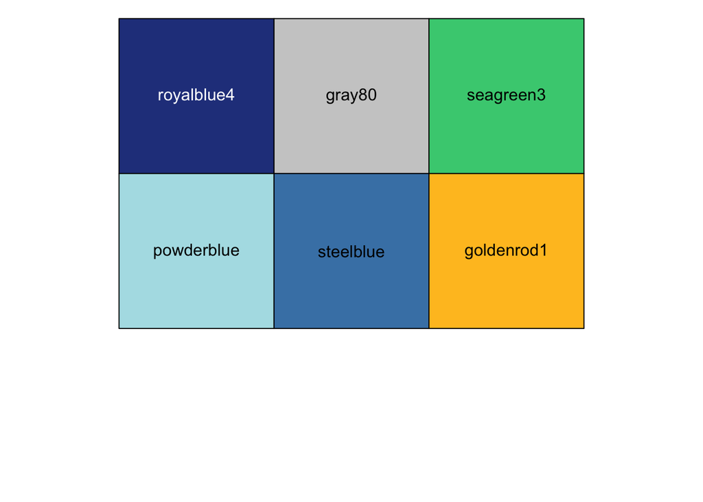

```r
# 自定义颜色
# Custom color
cols <- c("royalblue4","gray80","seagreen3","powderblue","steelblue","goldenrod1")
fills <- c("#FFFFD4","#FEE391","#FEC44F","#FE9929","#D95F0E")
# 查看颜色
# View colors
library(scales)
show_col(cols)
```

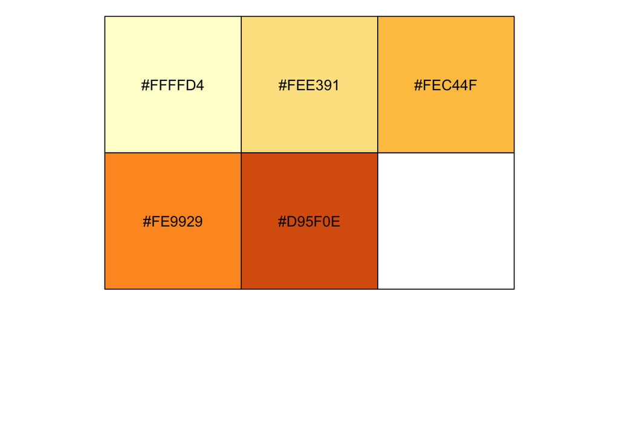

```r
show_col(fills)
```

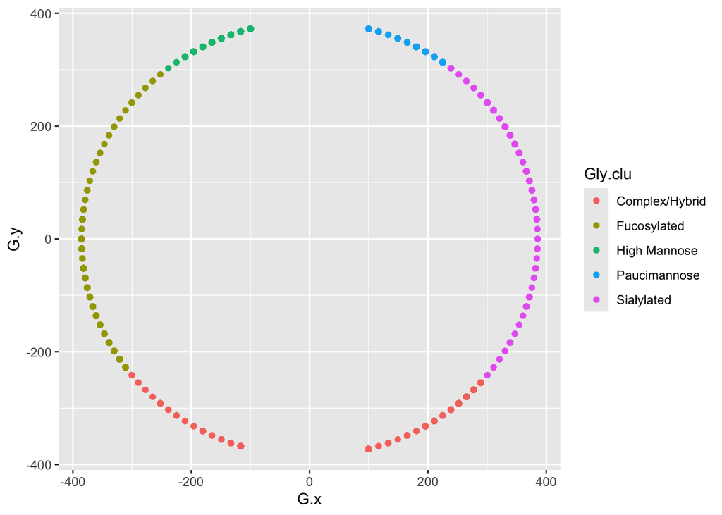

```r
# 画点
# Draw points
p <- ggplot(all1) +
  geom_point(aes(G.x,G.y,color=Gly.clu))
p
```

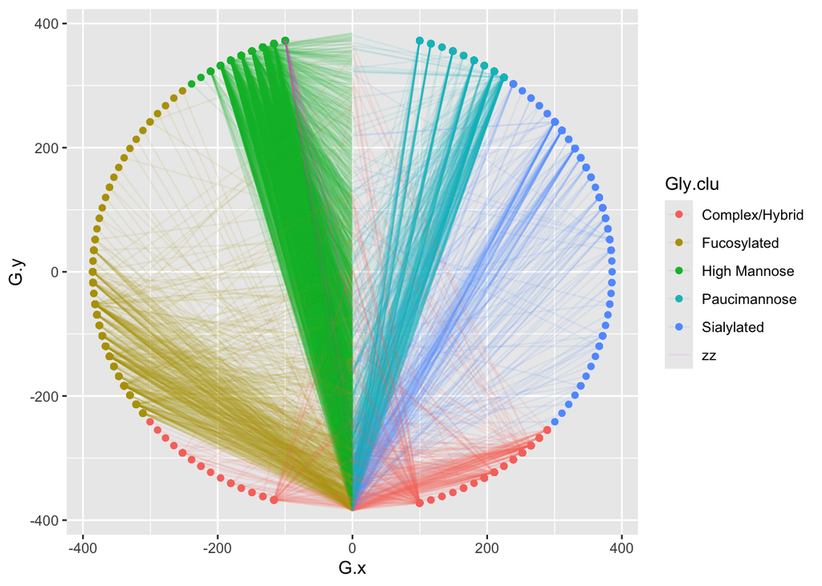

```r
# 画连线
# Draw lines
p1 <- p +
  geom_segment(aes(x=G.x,y=G.y,xend=P.x,yend=P.y,color=seg.clu),alpha=0.1)
p1
```

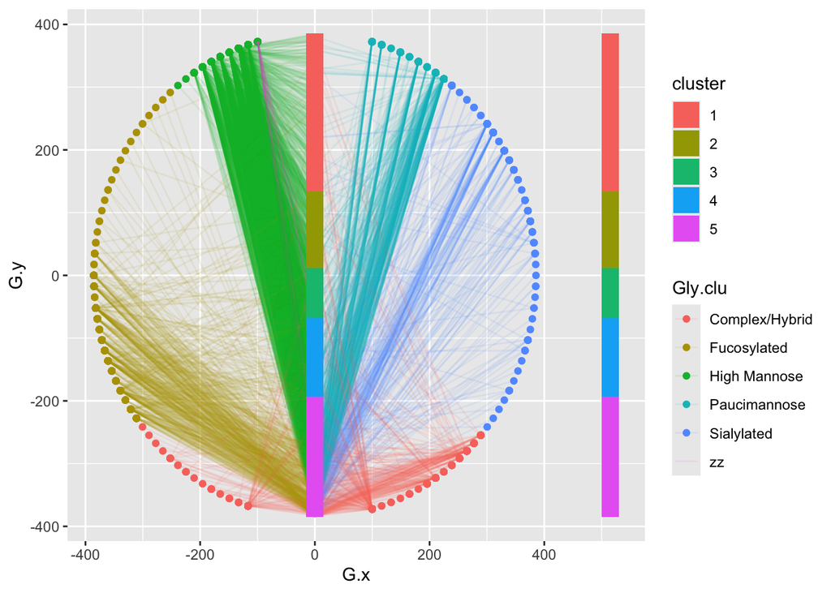

```r
# 画矩形
# Draw rectangles
p2 <- p1 +
  geom_rect(aes(xmin=-15,xmax=15,ymin=P.y,ymax=P.y+1,fill=cluster)) +
  geom_rect(aes(xmin=500,xmax=530,ymin=P.y,ymax=P.y+1,fill=cluster))
p2
```

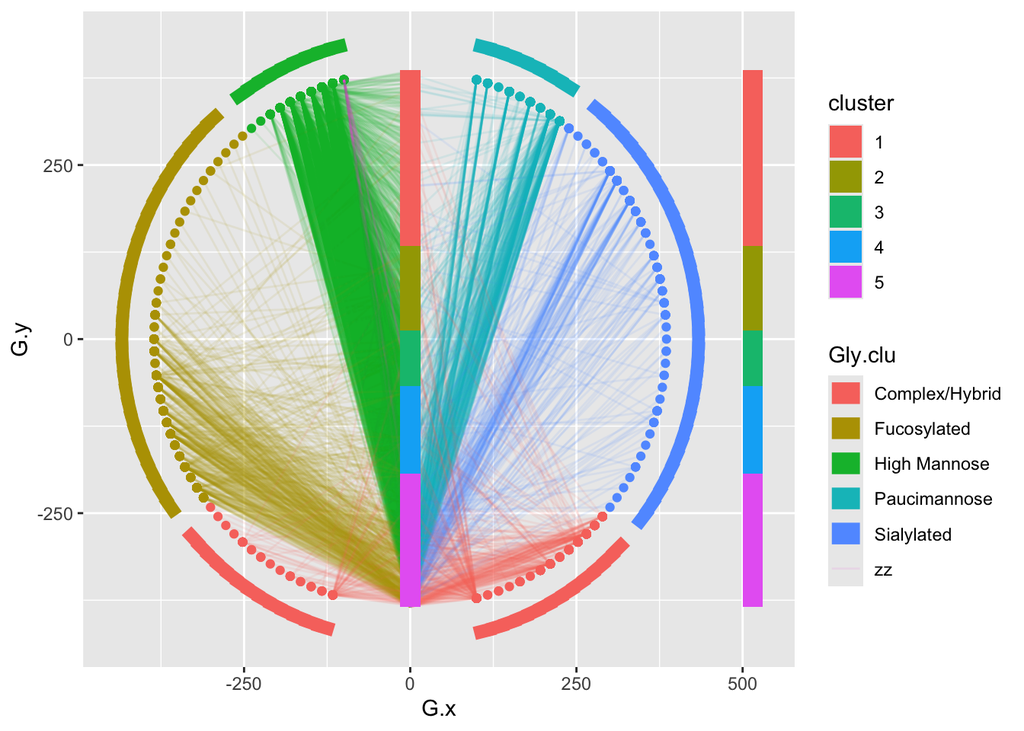

```r
# 画弧线
# Draw an arc
p3 <- p2 +
  geom_segment(data=curve,aes(x=x.start,xend=x.end,y=y.start,yend=y.end,color=Gly.clu),size=5)
p3
```

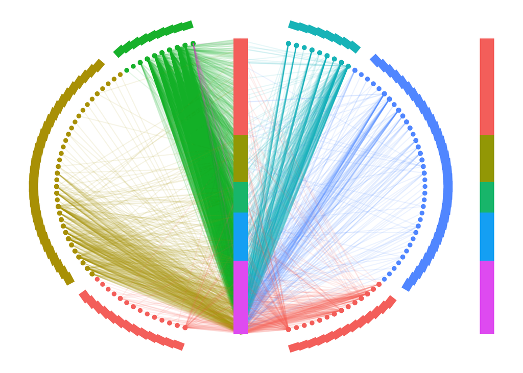

```r
# 清空背景和坐标轴
# Clear background and coordinate axes
p4 <- p3 +
  theme_minimal() +
  theme(
    legend.position = "none",
    axis.text = element_blank(),
    axis.title = element_blank(),
    panel.grid = element_blank()
    )
p4
```

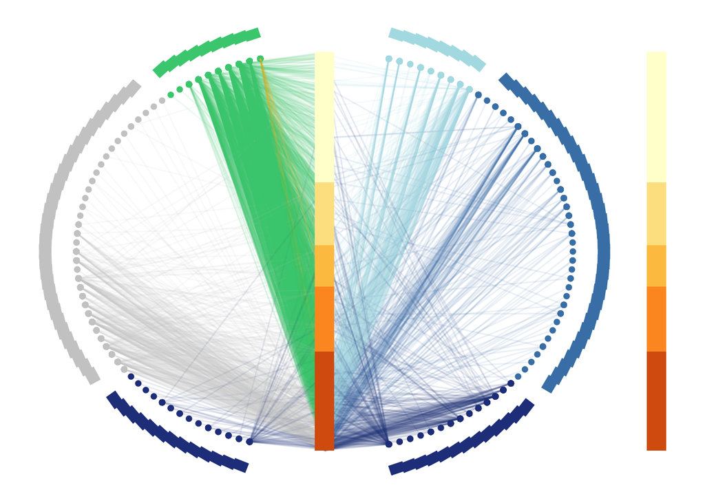

```r
# 用自定义颜色填充和画线
# Fill and draw lines with custom colors
p5 <- p4 +
  scale_color_manual(values=cols) +
  scale_fill_manual(values=fills)
p5
```

```r
# 输出到文件
# Output to file
pdf(file="target.pdf", height=5, width=5.5)
 p5
dev.off()
```

## 后期处理

## Post-processing

输出的PDF文件是矢量图，可以用PS或AI等矢量图编辑器打开，编辑图形和文字。 The output PDF file is a vector image, which can be opened with vector image editors such as PS or AI to edit graphics and text.

其实本来文字和数字都是可以在R中加的，但是还需要计算位置，莫不如在PS里修改。这里有一个PS的中间文件可以参考`target.psd`和`target.tif`。 Actually, text and numbers can be added in R, but the position needs to be calculated, so it is better to modify them in PS. Here is a PS intermediate file for reference `target.psd` and `target.tif`.

在用到自己数据的时候，最好先把原数据跑一遍，理解每个数字的含义，和整体的思路，再去举一反三。这里涉及到一些数学的三角函数计算，和角度的计算，还是要理解每个数字的含义的。 When using your own data, it is best to run the original data first, understand the meaning of each number, and the overall idea, and then draw inferences from one example. This involves some mathematical trigonometric function calculations and angle calculations, and you still need to understand the meaning of each number.